# ABSTRACT

#### Identify the most costly ingredients for all cuisines combined

The top costly ingredients among all cuisines and compared to the ranking of pork frequently used in Filipino cuisine.

```python
# Check for top ingredients in general (regardless of cuisine)
df_top5_ing_per_cuisine = pd.read_sql(
    """
    WITH RankedIngredients AS (
        SELECT
            cuisine,
            ingredient_key,
            SUM((INSURANCE * EXCHANGE_RATE + ARRASTRE * EXCHANGE_RATE
            + VATTAXBASE + DUTIESTAXES) / NETMASSKGS) AS COST_PER_NETMASS,
        RANK() OVER (
            PARTITION BY
                cuisine
            ORDER BY
                SUM((INSURANCE * EXCHANGE_RATE + ARRASTRE * EXCHANGE_RATE +
                VATTAXBASE + DUTIESTAXES) / NETMASSKGS) DESC)
                    AS ingredient_rank
        FROM consolidated
        GROUP BY
            cuisine,
            ingredient_key
        )
    SELECT
        cuisine,
        ingredient_key,
        COST_PER_NETMASS
    FROM
        RankedIngredients
    WHERE
        ingredient_rank <= 5
    ORDER BY
        COST_PER_NETMASS desc;
    """,
    conn)

df_top5_ing_per_cuisine.head(15)
```

|  | cuisine | ingredient_key | COST_PER_NETMASS |
| --- | --- | --- | --- |
| 0 | filipino | pork | 5.477061e+06 |
| 1 | korean | beef | 5.090617e+06 |
| 2 | indian | chili | 3.426677e+06 |
| 3 | korean | chili | 3.426677e+06 |
| 4 | mexican | chili | 3.426677e+06 |
| 5 | thai | chili | 3.426677e+06 |
| 6 | vietnamese | chili | 3.426677e+06 |
| 7 | spanish | saffron | 3.352402e+06 |
| 8 | brazilian | cheese | 1.772947e+06 |
| 9 | british | cheese | 1.772947e+06 |
| 10 | greek | cheese | 1.772947e+06 |
| 11 | italian | cheese | 1.772947e+06 |
| 12 | mexican | cheese | 1.772947e+06 |
| 13 | southern_us | cheese | 1.772947e+06 |
| 14 | french | red wine | 6.452069e+05 |

#### Check for trends in pork prices for potential signs of shortage

The cost per kgs of pork was graphed to identify any potential trends that would imply a shortage that could lead to high costs for importation.

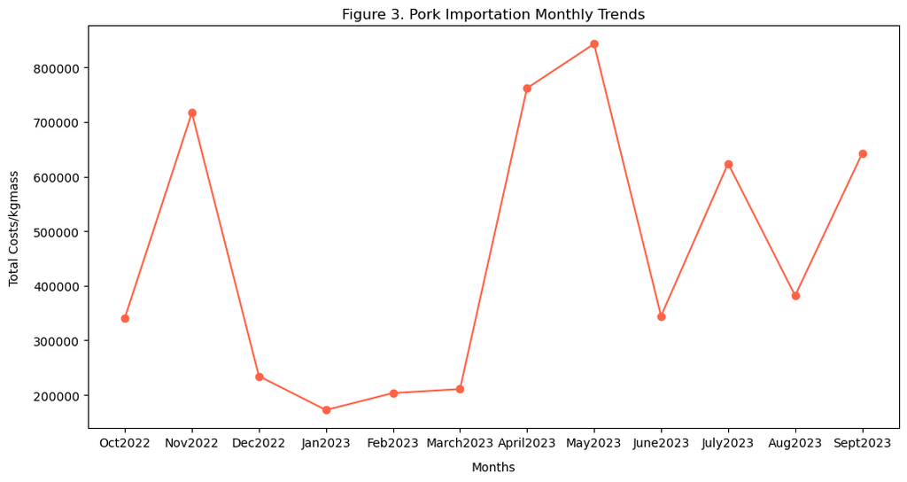

```python
df_pork_trend = pd.read_sql(
    """
    SELECT
        Month,
        ingredient_key,
        SUM((INSURANCE * EXCHANGE_RATE + ARRASTRE * EXCHANGE_RATE +
        VATTAXBASE + DUTIESTAXES) / NETMASSKGS) AS total_cost
    FROM
        consolidated
    WHERE
        ingredient_key LIKE '%pork%'
    GROUP BY
        Month, ingredient_key;
    """,
    conn)

total_costs = [df_pork_trend[df_pork_trend['Month'] == month]['total_cost']
               .values[0] for month in months]

fig = plt.figure(figsize=(12, 6))
ax = plt.subplot(111)
ax.plot(months, total_costs, marker='o', linestyle='-', color='tomato')
ax.set_title('Figure 3. Pork Importation Monthly Trends')
ax.set_xlabel('Months', labelpad=10)
ax.set_ylabel('Total Costs/kgmass', labelpad=10)
plt.show()
```

The graph was inconclusive as there was no identified trend that could sufficiently conclude a shortage occurring.

In conclusion, the following additional insights were gathered from the exploratory data analysis:

- **The analysis reveals that pork is a widely used ingredient in Filipino cuisine, appearing in at least 26% of Filipino dishes, and it ranks among the top 10 popular ingredients. The ingredient's popularity is confirmed by the high frequency of its use in Filipino recipes. However, it's not just its popularity that stands out; it's also among the top costly ingredients to import, with a significantly higher cost per kilogram compared to other common ingredients in various cuisines. This confirms the initial presumption that pork is generally an expensive ingredient to import. Additionally, the result underscores the cost significance of beef in Korean cuisine, which is comparable to Filipino cuisine. This highlights the intriguing observation of beef's substantial cost, influenced by factors such as K-Pop and cultural trends in the Philippines.**
- **Pork is one of the most expensive top ingredienst amongst all cuisines. In response to this, businesses may explore alternative sourcing strategies to manage ingredient costs. Exploring local suppliers or seeking cost-effective international sources can help mitigate the impact on pricing in case there are issues with the importation process.**

# C. Analysis for Recommendations

The study further investigated into the trends of exporter countries for pork based on two categories:

1. Highest in volume
2. Highest in costs per kgs

#### Top Exporter Countries for Pork (Volume)

```python
# Identify top exporter countries for pork (volume)
df_exporters_volume = pd.read_sql(
    """
    WITH IngredientVolume AS (
        SELECT
            cuisine,
            ingredient_key,
            COUNTRYEXPORT,
            SUM(NETMASSKGS) AS TOTAL_MASS
        FROM
            consolidated
        WHERE
            ingredient_key = 'pork'
        GROUP BY
            cuisine, ingredient_key, COUNTRYEXPORT
    )
    SELECT
        cuisine,
        ingredient_key,
        COUNTRYEXPORT,
        TOTAL_MASS,
        (TOTAL_MASS / SUM(TOTAL_MASS) OVER ()) * 100
            AS TOTAL_MASS_PERCENT
    FROM
        IngredientVolume
    ORDER BY
        TOTAL_MASS_PERCENT desc;
    """,
    conn)

df_exporters_volume.head(10)
```

|  | cuisine | ingredient_key | COUNTRYEXPORT | TOTAL_MASS | TOTAL_MASS_PERCENT |
| --- | --- | --- | --- | --- | --- |
| 0 | filipino | pork | SPAIN | 1.501751e+08 | 24.751044 |
| 1 | filipino | pork | CANADA | 1.092988e+08 | 18.014036 |
| 2 | filipino | pork | BRAZIL | 9.709897e+07 | 16.003330 |
| 3 | filipino | pork | NETHERLANDS | 6.734298e+07 | 11.099107 |
| 4 | filipino | pork | UNITED STATES | 4.306305e+07 | 7.097419 |
| 5 | filipino | pork | FRANCE | 3.798045e+07 | 6.259734 |
| 6 | filipino | pork | DENMARK | 2.880236e+07 | 4.747050 |
| 7 | filipino | pork | UNITED KINGDOM | 2.155409e+07 | 3.552429 |
| 8 | filipino | pork | BELGIUM | 1.666909e+07 | 2.747310 |
| 9 | filipino | pork | IRELAND | 9.981113e+06 | 1.645033 |

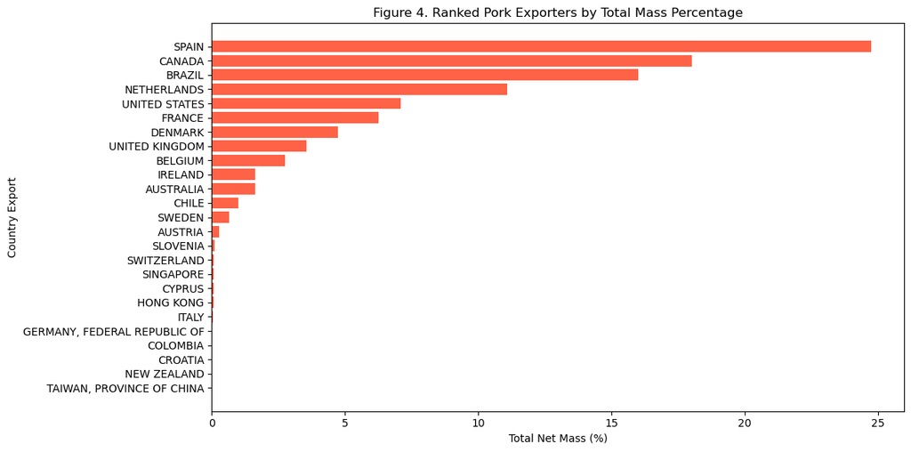

```python
plt.figure(figsize=(12, 6))
plt.barh(df_exporters_volume['COUNTRYEXPORT'],
         df_exporters_volume['TOTAL_MASS_PERCENT'], color='tomato')
plt.xlabel('Total Net Mass (%)')
plt.ylabel('Country Export')
plt.title('Figure 4. Ranked Pork Exporters by Total Mass Percentage')
plt.gca().invert_yaxis()
plt.tight_layout()
plt.show()
```

Based on the analysis, Spain was identified as the top exporter of pork to the Philippines in terms of volume, contributing **24%** of overall pork importation to the Philippines. Canada and Brazil rank 2nd and 3rd with a percentage of 18% and 16% respectively.

#### Top Exporter Countries for Pork (Cost per kgs)

```python
# Identify top exporter countries for pork (cost per kgs)
df_exporters_avg_cost_per_kg = pd.read_sql(
    """
    WITH IngredientCosts AS (
        SELECT
            cuisine,
            ingredient_key,
            COUNTRYEXPORT,
            AVG((INSURANCE * EXCHANGE_RATE + ARRASTRE * EXCHANGE_RATE +
            VATTAXBASE + DUTIESTAXES) / NETMASSKGS)
                AS AVG_COST_PER_KG
        FROM
            consolidated
        WHERE
            ingredient_key = 'pork'
        GROUP BY
            cuisine, ingredient_key, COUNTRYEXPORT
    )
    SELECT
        cuisine,
        ingredient_key,
        COUNTRYEXPORT,
        AVG_COST_PER_KG
    FROM
        IngredientCosts
    ORDER BY
        AVG_COST_PER_KG desc;
    """,
    conn)

df_exporters_avg_cost_per_kg.head(20)
```

|  | cuisine | ingredient_key | COUNTRYEXPORT | AVG_COST_PER_KG |
| --- | --- | --- | --- | --- |
| 0 | filipino | pork | TAIWAN, PROVINCE OF CHINA | 2076.237339 |
| 1 | filipino | pork | UNITED KINGDOM | 622.788731 |
| 2 | filipino | pork | FRANCE | 431.966158 |
| 3 | filipino | pork | UNITED STATES | 345.904385 |
| 4 | filipino | pork | BRAZIL | 249.605641 |
| 5 | filipino | pork | CANADA | 213.831064 |
| 6 | filipino | pork | GERMANY, FEDERAL REPUBLIC OF | 202.202864 |
| 7 | filipino | pork | DENMARK | 140.439149 |
| 8 | filipino | pork | SLOVENIA | 131.674789 |
| 9 | filipino | pork | BELGIUM | 130.409051 |
| 10 | filipino | pork | ITALY | 130.374785 |
| 11 | filipino | pork | NETHERLANDS | 128.717939 |
| 12 | filipino | pork | SWEDEN | 126.209865 |
| 13 | filipino | pork | CROATIA | 121.476849 |
| 14 | filipino | pork | CHILE | 119.735420 |
| 15 | filipino | pork | SPAIN | 115.027091 |
| 16 | filipino | pork | COLOMBIA | 114.732446 |
| 17 | filipino | pork | AUSTRIA | 112.113481 |
| 18 | filipino | pork | NEW ZEALAND | 102.994152 |
| 19 | filipino | pork | AUSTRALIA | 102.986784 |

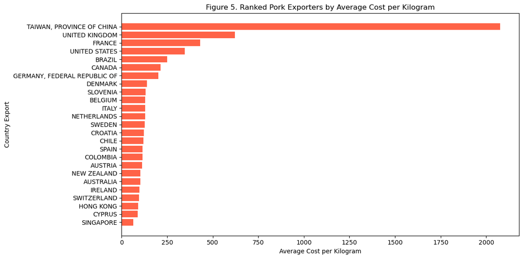

```python
plt.figure(figsize=(12, 6))
plt.barh(df_exporters_avg_cost_per_kg['COUNTRYEXPORT'],
         df_exporters_avg_cost_per_kg['AVG_COST_PER_KG'], color='tomato')
plt.xlabel('Average Cost per Kilogram')
plt.ylabel('Country Export')
plt.title('Figure 5. Ranked Pork Exporters by Average Cost per Kilogram')
plt.gca().invert_yaxis()
plt.tight_layout()
plt.show()
```

As an aside, while Taiwan contributes for the most costly exporter of pork to the Philippines, they do not contribute to a significant percentage of the overall volume of pork imported in the Philippines.

In conclusion:

- **Pork is a highly popular ingredient used in at least 26% of Filipino dishes and one of the most expensive top ingredient amongst all cuisines.**
- **Spain has the highest export volume of pork to the Philippines, with 24.75% of the total mass. This suggests that Spain is a reliable source for Filipino cuisine ingredients, particularly pork. Given that Spain offers a lower average cost per kilogram, it may be beneficial for the Philippines to negotiate trade agreements or partnerships with Spain to secure a stable and cost-effective source of pork.Diversify sources: While Spain, Canada, and Brazil are major exporters, it's important for the Philippines to diversify its sources of pork. This can help mitigate potential supply disruptions and price fluctuations. Consider exploring new trade relationships with countries that offer competitive prices.**
- **Canada and Brazil also contribute significantly to the supply of pork for Filipino cuisine, with 18.01% and 16.00% of the total mass, respectively. While Spain, Canada, and Brazil are major exporters, it's important for the Philippines to diversify its sources of pork. This can help mitigate potential supply disruptions and price fluctuations. Consider exploring new trade relationships with countries that offer competitive prices.**
- **The significant variation in the average cost per kilogram of pork among different exporting countries highlights that Taiwan may not be an ideal source of pork for the Philippines, despite its geographical proximity.**

# Results

Filipino cuisine's ingredients are the most costly to import both in terms of total cost and cost per kgs with a total cost of approximately 147.87 billion in Philippine Pesos. This suggests that importing Filipino cuisine-related products can be relatively expensive on a per-kilogram basis.

While Filipino cuisine is the most expensive per kilogram, various other cuisines like "Southern US," "Korean," "British," and "Irish" also have relatively high import costs per kilogram. This diversity highlights the different factors and products contributing to the cost structure of each cuisine.

Among the ingredients listed for Filipino cuisine, pork has the highest cost per net mass, almost 10 times the price of salt, which came second. Pork costs approximately 5.48 million Philippine Pesos per unit of net mass. This suggests that pork is a relatively expensive ingredient in Filipino cuisine in terms of cost per kilogram. Both salt and pepper have relatively low costs per net mass, which is common for basic seasonings. This suggests that these seasonings are readily available and inexpensive for Filipino cuisine, contributing to their frequent use.

For businesses involved in the food industry, understanding the cost of individual ingredients is crucial for pricing, cost management, and menu planning. Higher-cost ingredients like pork may impact the overall cost structure of Filipino dishes, potentially influencing menu prices.

Diversifying pork suppliers is crucial for the Philippines to manage supply disruptions and price fluctuations. Spain, Canada, and Brazil are significant contributors to the country's pork imports, with Spain leading at 24.75%. Despite Taiwan's proximity, its high pork cost per kilogram makes it an unsuitable source. Therefore, establishing trade agreements or partnerships with Spain, which offers a lower cost per kilogram, could prove advantageous for the Philippines.